# Practical Machine Learning Course Project

Fritz Lin

# 1 Introduction

## 1.1 Background

Using devices such as *Jawbone Up*, *Nike FuelBand*, and *Fitbit* it is now possible to collect a large amount of data about personal activity relatively inexpensively. These type of devices are part of the quantified self movement - a group of enthusiasts who take measurements about themselves regularly to improve their health, to find patterns in their behavior, or because they are tech geeks. One thing that people regularly do is quantify how *much* of a particular activity they do, but they rarely quantify *how well they do it*.

## 1.2 Project Goal

In this project, we will use data from accelerometers on the belt, forearm, arm, and dumbell of 6 participants. They were asked to perform barbell lifts in five different fashions: exactly according to the specification (Class A), throwing the elbows to the front (Class B), lifting the dumbbell only halfway (Class C), lowering the dumbbell only halfway (Class D) and throwing the hips to the front (Class E). Class A corresponds to the correct execution of the exercise, while the other 4 classes correspond to common mistakes.

Our goal is to predict the manner in which they did the exercise based on the set of accelerometers, which constitutes a classification problem. We make use of different machine learning algorithms to perform the predictions and evaluate their performances.

# 2 Data Processing

## 2.1 Data Import[^1]

We first load the required packages in R and then download the training and testing data sets from the provided links, if they are not already on the local machine. We also set a seed for the purpose of reproducibility.

```r
# required packages
library(caret); library(randomForest); library(rpart); library(e1071)
library(tidyverse); library(corrplot); library(gridExtra); library(Hmisc)

set.seed(2343)
```

```r
# download data
urlTrain <- "https://d396qusza40orc.cloudfront.net/predmachlearn/pml-training.csv"
urlTest <- "https://d396qusza40orc.cloudfront.net/predmachlearn/pml-testing.csv"
fileTrain <- "./data/pml-training.csv"
fileTest <- "./data/pml-testing.csv"

if (!file.exists("./data")) {
  dir.create("./data")
}
if (!file.exists(fileTrain)){
  download.file(urlTrain, fileTrain, method = "curl")
}
if (!file.exists(fileTest)){
  download.file(urlTest, fileTest, method = "curl")
}

# import data
trainRaw <- read.csv(fileTrain)
testRaw <- read.csv(fileTest)

rbind("training set" = dim(trainRaw), "testing set" = dim(testRaw))
```

```
##               [,1] [,2]
## training set 19622  160
## testing set     20  160
```

The training set contains 19622 observations and 160 variables, while the testing set has 20 observations with the same variables. The variable that describes the manner in which the participants did the barbell lifts and that we would like to predict is stored in the `classe` variable.

## 2.2 Data Cleaning

Next, we clean our training data set from missing values as well as any variables that has near zero variance and variables that we believe are not pertinent to the prediction of the response variable. The last step was performed as a result of our exploratory analysis (see Exploratory Analysis)

```r
# exclude variables with missing values
M <- colSums(is.na(trainRaw))
varMiss <- M[M>0]
trainM <- trainRaw[, M==0]

# exclude variables with near zero variance
varNZV <- nearZeroVar(trainM, saveMetrics = T)
trainNZV <- trainM[, !varNZV$nzv]

# exclude unrelated variables
trainClean <- trainNZV[,-c(1:6)]

rbind("clean training set" = dim(trainClean))
```

```
##                     [,1] [,2]
## clean training set 19622   53
```

We end up with a cleaned training data set `trainClean` of 53 variables, that is, we have 52 features and 1 response. The features remaining in the set come from the accelerometers on the belt, forearm, arm, and dumbell and are as follow (13 measurements for each accelerometer):

```r
colnames(subset(trainClean, select=-c(classe)))
```

```
##  [1] "roll_belt"            "pitch_belt"           "yaw_belt"
##  [4] "total_accel_belt"     "gyros_belt_x"         "gyros_belt_y"
##  [7] "gyros_belt_z"         "accel_belt_x"         "accel_belt_y"
## [10] "accel_belt_z"         "magnet_belt_x"        "magnet_belt_y"
## [13] "magnet_belt_z"        "roll_arm"             "pitch_arm"
## [16] "yaw_arm"              "total_accel_arm"      "gyros_arm_x"
## [19] "gyros_arm_y"          "gyros_arm_z"          "accel_arm_x"
## [22] "accel_arm_y"          "accel_arm_z"          "magnet_arm_x"
## [25] "magnet_arm_y"         "magnet_arm_z"         "roll_dumbbell"
## [28] "pitch_dumbbell"       "yaw_dumbbell"         "total_accel_dumbbell"
## [31] "gyros_dumbbell_x"     "gyros_dumbbell_y"     "gyros_dumbbell_z"
## [34] "accel_dumbbell_x"     "accel_dumbbell_y"     "accel_dumbbell_z"
## [37] "magnet_dumbbell_x"    "magnet_dumbbell_y"    "magnet_dumbbell_z"
## [40] "roll_forearm"         "pitch_forearm"        "yaw_forearm"
## [43] "total_accel_forearm"  "gyros_forearm_x"      "gyros_forearm_y"
## [46] "gyros_forearm_z"      "accel_forearm_x"      "accel_forearm_y"
## [49] "accel_forearm_z"      "magnet_forearm_x"     "magnet_forearm_y"
## [52] "magnet_forearm_z"
```

## 2.3 Data slicing

Next, we split our training set into a sub-training and a validation set so as to test out different prediction algorithms with different parameters and select the best performing one.

```r
# data slicing
inTrain <- createDataPartition(y=trainClean$classe, p=0.7, list=FALSE)
training <- trainClean[inTrain, ]
validation <- trainClean[-inTrain, ]

rbind("sub-training set" = dim(training),"validation set" = dim(validation))
```

```
##                   [,1] [,2]
## sub-training set 13737   53
## validation set    5885   53
```

# 3 Exploratory Analysis

## 3.1 Variable Exclusion

One of the first things we note, when we perform our exploratory analysis on the raw training data is that some of the variables included are more of a descriptive nature. One such variable is `user_name` and also `X`, others are related to the timestamps or to a “sliding window” to measure the barbell lifts.

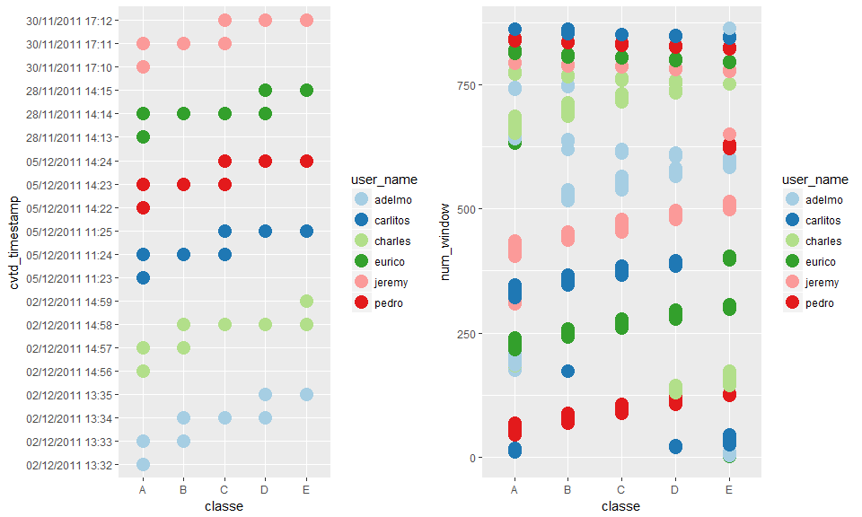

```r
g1 <- ggplot(trainRaw, aes(x=classe, y=cvtd_timestamp, colour=user_name)) +
  geom_point(shape=19, size=5) + scale_colour_brewer(palette = "Paired")
g2 <- ggplot(trainRaw, aes(x=classe, y=num_window, colour=user_name)) +
  geom_point(shape=19, size=5) + scale_colour_brewer(palette = "Paired")
grid.arrange(g1,g2, ncol=2)
```

It is evident from the above plots that the excercises performed by the participants were done in temporal order (A $\rightarrow$ B $\rightarrow$ C, etc.). If we would train our models on these variables, we would heavily bias our predictions. We therefore exclude those.

## 3.2 Response Variable

Before prediction models are fit, it would be useful to have a sense of the frequency in the classification of our respone. This will help us in determining a best model for prediction.

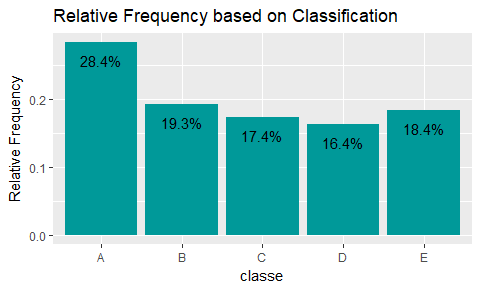

```r
freqClasse <- table(training$classe)
propClasse <- table(freqClasse)
ggplot(data=training, aes(x=classe)) +
  geom_bar(aes(y=(..count..)/sum(..count..)), fill="#009999") +
  geom_text(aes(y=((..count..)/sum(..count..)),
                label=scales::percent((..count..)/sum(..count..))),
            stat = "count", vjust = 2) +
  labs(y="Relative Frequency", title="Relative Frequency based on Classification")
```

## 3.3 Feature variables

To get a better sense of our feature variables we draw a correlogram that can be used to examine the data for multicollinearity. We could then exclude those variables directly from our prediction models or perform a principal component analysis (PCA) on them to reduce the dimensionality as well as noise of the data.

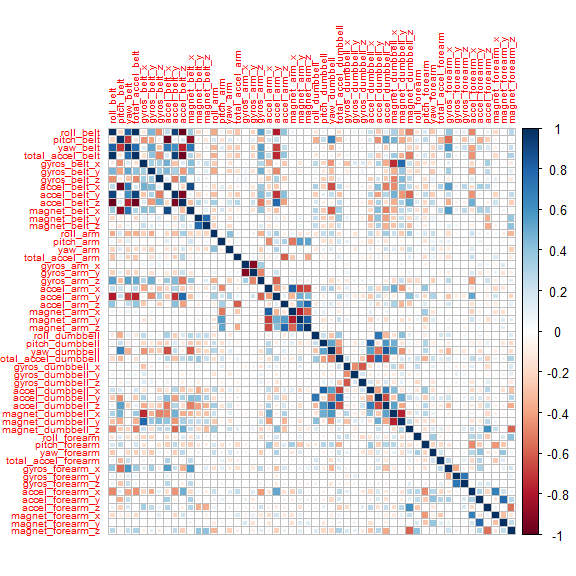

```r
corr <- cor(subset(training, select=-c(classe)))
par(xpd=TRUE)
corrplot(corr, method="square", tl.cex=0.6, mar = c(2, 0, 1, 0))
```

We do see correlations within each accelerometers (belt, arm, dumpbell, forearm) as well as between arm and belt, and between dumpbell and belt.

```r
hist(subset(training, select=-c(classe)))
```

[output not shown]

Our initial fits have shown a high accuracy rate when we chose a random forest as our prediction model, we therefore conclude that variable exclusion or any transformations of the data were not necessary.

# 4 Prediction Algorithm

The following algorithms were chosen for our classifaction problem:

- Classification Trees (CART)
- Random Forest
- Boosting with Trees (Stochastic Gradient Boosting Trees)
- Linear Discriminant Analysis
- Support Vector Machines

Because the *random forest* and the *stochastic gradient boosting trees* algorithms took considerable more time to train a model, we have reduced the number of folds for the k-fold cross-validation to $k=4$, so as to save some computation time. It appears to have not a great impact on the performance, nonetheless. All other algorithms are trained with default parameters. The code is given below:

```r
if (!file.exists("./training")) {
  dir.create("./training")
}

# Prediction using Classification Trees
if (!file.exists("./training/modelRpart.RData")){
  # method="class" indicates that response is a factor variable
  modRpart <- train(classe ~ ., data=training, method="rpart",
                  control = rpart.control(method="class"))
  # Note: different results when using rpart directly
  # modRpart <- rpart(classe ~ ., data=training, method="class")
  save(modRpart, file="./training/modelRpart.RData")
} else {
  load("./training/modelRpart.RData")
}

predictRpart <- predict(modRpart, validation)
# predictRpart <- predict(modRpart, validation, type="class")

confMatRpart <- confusionMatrix(validation$classe, predictRpart)
```

```r
# Prediction using Random Forest
if (!file.exists("./training/modelRf.RData")){
  fitControl <- trainControl(method = "cv", number = 4)
  modRf <- train(classe ~ ., data=training, method="rf",
                 trControl = fitControl)
  # modRf <- randomForest(classe ~ ., data=training)
  save(modRf, file="./training/modelRf.RData")
} else {
  load("./training/modelRf.RData")
}

predictRf <- predict(modRf, validation)
confMatRf <- confusionMatrix(validation$classe, predictRf)
```

```r
# Prediction using Boosting with Trees
if (!file.exists("./training/modelGbm.RData")){
  fitControl <- trainControl(method = "cv", number = 4)
  modGbm <- train(classe ~ ., data=training, method="gbm",
                  verbose=FALSE, trControl=fitControl)
  save(modGbm, file="./training/modelGbm.RData")
} else {
  load("./training/modelGbm.RData")
}
predictGbm <- predict(modGbm, validation)
confMatGbm <- confusionMatrix(validation$classe, predictGbm)
```

```r
# Prediction using Linear Discriminant Analysis
if (!file.exists("./training/modelLda.RData")){
  modLda <- train(classe ~ ., data=training, method="lda")
  save(modLda, file="./training/modelLda.RData")
} else {
  load("./training/modelLda.RData")
}
predictLda <- predict(modLda, validation)
confMatLda <- confusionMatrix(validation$classe, predictLda)
```

```r
# Prediction using Support Vector Machines
if (!file.exists("./training/modelSvm.RData")){
  modSvm <- svm(classe ~ ., data=training)
  save(modSvm, file="./training/modelSvm.RData")
} else {
  load("./training/modelSvm.RData")
}
predictSvm <- predict(modSvm, validation)
confMatSvm <- confusionMatrix(validation$classe, predictSvm)
```

The results of the different algorithms are as follow:

```r
results <- data.frame("Algorithm" = c("Decision Trees", "Random Forest",
                                "Stochastic Gradient Boosting Trees",
                                "Linear Discriminant Analysis",
                                "Support Vector Machines"),
                      Accuracy = rbind(confMatRpart$overall[1],
                                       confMatRf$overall[1],
                                       confMatGbm$overall[1],
                                       confMatLda$overall[1],
                                       confMatSvm$overall[1]))
results
```

```
##                            Algorithm  Accuracy
## 1                     Decision Trees 0.4961767
## 2                      Random Forest 0.9938828
## 3 Stochastic Gradient Boosting Trees 0.9622770
## 4       Linear Discriminant Analysis 0.6946474
## 5            Support Vector Machines 0.9536109
```

From the table we see prediction using *random forest* has the highest accuracy rate, followed by *stochastic gradient boosting trees* and *support vector machines*. We note, however, that the former two algorithms took considerable more time to train than the latter. Nonetheless, we choose the *random forest* as our prediction model. Below we print its confusion matrix as well as some summary statistics:

```r
# Validation vs Truth in relative terms (cmp with section 3.2)
# round(prop.table(table(predictRf, validation$classe)),4)

# Confusion Matrix for Random Tree Model
confMatRf
```

```
## Confusion Matrix and Statistics
##
##           Reference
## Prediction    A    B    C    D    E
##          A 1671    2    0    0    1
##          B    9 1125    5    0    0
##          C    0    5 1016    5    0
##          D    0    0    6  957    1
##          E    0    0    1    1 1080
##
## Overall Statistics
##
##                Accuracy : 0.9939
##                  95% CI : (0.9915, 0.9957)
##     No Information Rate : 0.2855
##     P-Value [Acc > NIR] : < 2.2e-16
##
##                   Kappa : 0.9923
##  Mcnemar's Test P-Value : NA
##
## Statistics by Class:
##
##                      Class: A Class: B Class: C Class: D Class: E
## Sensitivity            0.9946   0.9938   0.9883   0.9938   0.9982
## Specificity            0.9993   0.9971   0.9979   0.9986   0.9996
## Pos Pred Value         0.9982   0.9877   0.9903   0.9927   0.9982
## Neg Pred Value         0.9979   0.9985   0.9975   0.9988   0.9996
## Prevalence             0.2855   0.1924   0.1747   0.1636   0.1839
## Detection Rate         0.2839   0.1912   0.1726   0.1626   0.1835
## Detection Prevalence   0.2845   0.1935   0.1743   0.1638   0.1839
## Balanced Accuracy      0.9970   0.9954   0.9931   0.9962   0.9989
```

The `varImp` function in R helps us to identify the variables with the greatest importance in our model.

```r
impRf <- varImp(modRf)
impRf
```

```
## rf variable importance
##
##   only 20 most important variables shown (out of 52)
##
##                      Overall
## roll_belt             100.00
## pitch_forearm          60.16
## yaw_belt               51.84
## pitch_belt             44.67
## magnet_dumbbell_y      44.62
## magnet_dumbbell_z      43.39
## roll_forearm           42.64
## accel_dumbbell_y       21.68
## accel_forearm_x        17.48
## roll_dumbbell          17.41
## magnet_dumbbell_x      16.47
## magnet_belt_z          16.41
## accel_belt_z           14.42
## total_accel_dumbbell   13.75
## magnet_forearm_z       13.49
## accel_dumbbell_z       13.36
## magnet_belt_y          12.41
## gyros_belt_z           11.93
## magnet_belt_x          10.60
## yaw_arm                10.48
```

# 5 Test Set Predictions

Now that we have selected a model using the random forest algorithm as our final prediction model, we apply it to our 20 cases in the testing data set.

```r
predictTesting <- predict(modRf, testRaw)
predictTesting
```

```
##  [1] B A B A A E D B A A B C B A E E A B B B
## Levels: A B C D E
```

[^1]: The data for this project was kindly provided from this source: http://web.archive.org/web/20161224072740/http:/groupware.les.inf.puc-rio.br/har